# Project1

Rohan Prabhune

2022-09-14

This project report follows the steps given in the instructions pdf file

# Data Procesisng

## First Steps

### Read the csv

This step uses `read_csv()` function to read in the csv as a tibble.

```r
# Install the necessary packages for the project
library(readr)
library(dplyr)
library(tidyr)
library(stringr)
# Reading the csv
sheet1 <- read_csv("https://www4.stat.ncsu.edu/~online/datasets/EDU01a.csv")
sheet1
```

```
## # A tibble: 3,198 × 42
##    Area_…¹ STCOU EDU01…² EDU01…³ EDU01…⁴ EDU01…⁵ EDU01…⁶ EDU01…⁷ EDU01…⁸ EDU01…⁹
##    <chr>   <chr>   <dbl>   <dbl> <chr>   <chr>     <dbl>   <dbl> <chr>   <chr>
##  1 UNITED… 00000       0  4.00e7 0000    0000          0  4.00e7 0000    0000
##  2 ALABAMA 01000       0  7.34e5 0000    0000          0  7.28e5 0000    0000
##  3 Autaug… 01001       0  6.83e3 0000    0000          0  6.9 e3 0000    0000
##  4 Baldwi… 01003       0  1.64e4 0000    0000          0  1.65e4 0000    0000
##  5 Barbou… 01005       0  5.07e3 0000    0000          0  5.10e3 0000    0000
##  6 Bibb, … 01007       0  3.56e3 0000    0000          0  3.51e3 0000    0000
##  7 Blount… 01009       0  7.32e3 0000    0000          0  7.22e3 0000    0000
##  8 Bulloc… 01011       0  2.01e3 0000    0000          0  1.98e3 0000    0000
##  9 Butler… 01013       0  4.64e3 0000    0000          0  4.58e3 0000    0000
## 10 Calhou… 01015       0  2.09e4 0000    0000          0  2.09e4 0000    0000
## # … with 3,188 more rows, 32 more variables: EDU010189F <dbl>,
## #   EDU010189D <dbl>, EDU010189N1 <chr>, EDU010189N2 <chr>, EDU010190F <dbl>,
## #   EDU010190D <dbl>, EDU010190N1 <chr>, EDU010190N2 <chr>, EDU010191F <dbl>,
## #   EDU010191D <dbl>, EDU010191N1 <chr>, EDU010191N2 <chr>, EDU010192F <dbl>,
## #   EDU010192D <dbl>, EDU010192N1 <chr>, EDU010192N2 <chr>, EDU010193F <dbl>,
## #   EDU010193D <dbl>, EDU010193N1 <chr>, EDU010193N2 <chr>, EDU010194F <dbl>,
## #   EDU010194D <dbl>, EDU010194N1 <chr>, EDU010194N2 <chr>, EDU010195F <dbl>, …
```

### Step1

This steps uses `select()` function to take a subset of columns and uses `rename()` function to rename “Area_name” to “area_name”.

```r
sheet2 <- sheet1 %>% select("Area_name","STCOU",ends_with("D")) %>% rename("area_name" = Area_name)
sheet2
```

```
## # A tibble: 3,198 × 12
##    area_…¹ STCOU EDU01…² EDU01…³ EDU01…⁴ EDU01…⁵ EDU01…⁶ EDU01…⁷ EDU01…⁸ EDU01…⁹
##    <chr>   <chr>   <dbl>   <dbl>   <dbl>   <dbl>   <dbl>   <dbl>   <dbl>   <dbl>
##  1 UNITED… 00000  4.00e7  4.00e7  4.03e7  4.07e7  4.14e7  4.21e7  4.27e7  4.34e7
##  2 ALABAMA 01000  7.34e5  7.28e5  7.30e5  7.28e5  7.26e5  7.26e5  7.28e5  7.31e5
##  3 Autaug… 01001  6.83e3  6.9 e3  6.92e3  6.85e3  7.01e3  7.14e3  7.15e3  7.38e3
##  4 Baldwi… 01003  1.64e4  1.65e4  1.68e4  1.71e4  1.75e4  1.80e4  1.87e4  1.94e4
##  5 Barbou… 01005  5.07e3  5.10e3  5.07e3  5.16e3  5.17e3  5.25e3  5.14e3  5.11e3
##  6 Bibb, … 01007  3.56e3  3.51e3  3.57e3  3.62e3  3.65e3  3.56e3  3.56e3  3.55e3
##  7 Blount… 01009  7.32e3  7.22e3  7.20e3  7.21e3  7.16e3  7.15e3  7.21e3  7.3 e3
##  8 Bulloc… 01011  2.01e3  1.98e3  1.98e3  1.98e3  1.98e3  2.02e3  2.01e3  2.01e3
##  9 Butler… 01013  4.64e3  4.58e3  4.61e3  4.59e3  4.54e3  4.48e3  4.44e3  4.35e3
## 10 Calhou… 01015  2.09e4  2.09e4  2.09e4  2.08e4  2.08e4  2.05e4  2.05e4  2.01e4
## # … with 3,188 more rows, 2 more variables: EDU010195D <dbl>, EDU010196D <dbl>,
## #   and abbreviated variable names ¹area_name, ²EDU010187D, ³EDU010188D,
## #   ⁴EDU010189D, ⁵EDU010190D, ⁶EDU010191D, ⁷EDU010192D, ⁸EDU010193D,
## #   ⁹EDU010194D
```

### Step2

`pivot_longer()` function is used here to convert tibble to long format.

```r
sheet3 <- sheet2 %>% pivot_longer(cols=3:12,names_to="item_id",values_to="enrollment_value")
sheet3
```

```
## # A tibble: 31,980 × 4
##    area_name     STCOU item_id    enrollment_value
##    <chr>         <chr> <chr>                 <dbl>
##  1 UNITED STATES 00000 EDU010187D         40024299
##  2 UNITED STATES 00000 EDU010188D         39967624
##  3 UNITED STATES 00000 EDU010189D         40317775
##  4 UNITED STATES 00000 EDU010190D         40737600
##  5 UNITED STATES 00000 EDU010191D         41385442
##  6 UNITED STATES 00000 EDU010192D         42088151
##  7 UNITED STATES 00000 EDU010193D         42724710
##  8 UNITED STATES 00000 EDU010194D         43369917
##  9 UNITED STATES 00000 EDU010195D         43993459
## 10 UNITED STATES 00000 EDU010196D         44715737
## # … with 31,970 more rows
```

### Step3

Here `substr()` function is used to create new variables “year” and “enrollment_id” from an existing variable “item_id” by using index position of the values. `as.Date()` is used to convert string values to date format.

```r
sheet3$enrollment_id = substr(sheet3$item_id,1,7)
sheet3$year = substr(sheet3$item_id,8,9)
sheet3$year <- as.Date(sheet3$year,format="%y")
sheet3$year <- format(sheet3$year, "%Y")
sheet3$year <- as.integer(sheet3$year)
sheet3
```

```
## # A tibble: 31,980 × 6
##    area_name     STCOU item_id    enrollment_value enrollment_id  year
##    <chr>         <chr> <chr>                 <dbl> <chr>         <int>
##  1 UNITED STATES 00000 EDU010187D         40024299 EDU0101        1987
##  2 UNITED STATES 00000 EDU010188D         39967624 EDU0101        1988
##  3 UNITED STATES 00000 EDU010189D         40317775 EDU0101        1989
##  4 UNITED STATES 00000 EDU010190D         40737600 EDU0101        1990
##  5 UNITED STATES 00000 EDU010191D         41385442 EDU0101        1991
##  6 UNITED STATES 00000 EDU010192D         42088151 EDU0101        1992
##  7 UNITED STATES 00000 EDU010193D         42724710 EDU0101        1993
##  8 UNITED STATES 00000 EDU010194D         43369917 EDU0101        1994
##  9 UNITED STATES 00000 EDU010195D         43993459 EDU0101        1995
## 10 UNITED STATES 00000 EDU010196D         44715737 EDU0101        1996
## # … with 31,970 more rows
```

### Step4

`grep()` is used to fetch the index values which satisfies the condition given in the function. These index values are used to subset the original tibble into **county** and **state** tibbles. For the county level tibble, a class called ‘county’ is added to county tibble and similarly for the state level tibble, a class called ‘state’ is added to state tibble.

```r
county_index_vector <- grep(pattern = ", \\w\\w", sheet3$area_name)

county <- subset(sheet3, row.names(sheet3) %in% county_index_vector)
state <- subset(sheet3,!(row.names(sheet3) %in% county_index_vector))
state$area_name <- toupper(state$area_name)

class(county) <- c("county", class(county))
class(state) <- c("state", class(state))

county
```

```
## # A tibble: 31,450 × 6
##    area_name   STCOU item_id    enrollment_value enrollment_id  year
##    <chr>       <chr> <chr>                 <dbl> <chr>         <int>
##  1 Autauga, AL 01001 EDU010187D             6829 EDU0101        1987
##  2 Autauga, AL 01001 EDU010188D             6900 EDU0101        1988
##  3 Autauga, AL 01001 EDU010189D             6920 EDU0101        1989
##  4 Autauga, AL 01001 EDU010190D             6847 EDU0101        1990
##  5 Autauga, AL 01001 EDU010191D             7008 EDU0101        1991
##  6 Autauga, AL 01001 EDU010192D             7137 EDU0101        1992
##  7 Autauga, AL 01001 EDU010193D             7152 EDU0101        1993
##  8 Autauga, AL 01001 EDU010194D             7381 EDU0101        1994
##  9 Autauga, AL 01001 EDU010195D             7568 EDU0101        1995
## 10 Autauga, AL 01001 EDU010196D             7834 EDU0101        1996
## # … with 31,440 more rows
```

```r
state
```

```
## # A tibble: 530 × 6
##    area_name     STCOU item_id    enrollment_value enrollment_id  year
##    <chr>         <chr> <chr>                 <dbl> <chr>         <int>
##  1 UNITED STATES 00000 EDU010187D         40024299 EDU0101        1987
##  2 UNITED STATES 00000 EDU010188D         39967624 EDU0101        1988
##  3 UNITED STATES 00000 EDU010189D         40317775 EDU0101        1989
##  4 UNITED STATES 00000 EDU010190D         40737600 EDU0101        1990
##  5 UNITED STATES 00000 EDU010191D         41385442 EDU0101        1991
##  6 UNITED STATES 00000 EDU010192D         42088151 EDU0101        1992
##  7 UNITED STATES 00000 EDU010193D         42724710 EDU0101        1993
##  8 UNITED STATES 00000 EDU010194D         43369917 EDU0101        1994
##  9 UNITED STATES 00000 EDU010195D         43993459 EDU0101        1995
## 10 UNITED STATES 00000 EDU010196D         44715737 EDU0101        1996
## # … with 520 more rows
```

### Step5

`str_split_fixed()` function is used to split ‘area_name’ variable into 2 new variables ‘county_name’ and its corresponding ‘state’ based on the comma(,) delimiter.

```r
county[c('county_name', 'state')] <- str_split_fixed(county$area_name, ',', 2)
county$state <- trimws(county$state, which = c("both"))
county
```

```
## # A tibble: 31,450 × 8
##    area_name   STCOU item_id    enrollment_value enrollmen…¹  year count…² state
##    <chr>       <chr> <chr>                 <dbl> <chr>       <int> <chr>   <chr>
##  1 Autauga, AL 01001 EDU010187D             6829 EDU0101      1987 Autauga AL
##  2 Autauga, AL 01001 EDU010188D             6900 EDU0101      1988 Autauga AL
##  3 Autauga, AL 01001 EDU010189D             6920 EDU0101      1989 Autauga AL
##  4 Autauga, AL 01001 EDU010190D             6847 EDU0101      1990 Autauga AL
##  5 Autauga, AL 01001 EDU010191D             7008 EDU0101      1991 Autauga AL
##  6 Autauga, AL 01001 EDU010192D             7137 EDU0101      1992 Autauga AL
##  7 Autauga, AL 01001 EDU010193D             7152 EDU0101      1993 Autauga AL
##  8 Autauga, AL 01001 EDU010194D             7381 EDU0101      1994 Autauga AL
##  9 Autauga, AL 01001 EDU010195D             7568 EDU0101      1995 Autauga AL
## 10 Autauga, AL 01001 EDU010196D             7834 EDU0101      1996 Autauga AL
## # … with 31,440 more rows, and abbreviated variable names ¹enrollment_id,
## #   ²county_name
```

### Step6

For the state tibble, a new categorical variable ‘divison’ is created which based on the 9 divisions vector mentioned in the code. Here I have used boolean masking to extract states belonging to a particular division and used `mutate()` to add ‘divison’ variable.

```r
Division_1 <- c('CONNECTICUT','MAINE','MASSACHUSETTS','NEW HAMPSHIRE','RHODE ISLAND','VERMONT')
Division_2 <- c('NEW JERSEY','NEW YORK','PENNSYLVANIA')
Division_3 <- c('ILLINOIS','INDIANA','MICHIGAN','OHIO','WISCONSIN')
Division_4 <- c('IOWA','KANSAS','MINNESOTA','MISSOURI','NEBRASKA','NORTH DAKOTA','SOUTH DAKOTA')
Division_5 <- c('DELAWARE','FLORIDA','GEORGIA','MARYLAND','NORTH CAROLINA','SOUTH CAROLINA','VIRGINIA','DISTRICT OF COLUMBIA','WEST VIRGINIA')
Division_6 <- c('ALABAMA','KENTUCKY','MISSISSIPPI','TENNESSEE')
Division_7 <- c('ARKANSAS','LOUISIANA','OKLAHOMA','TEXAS')
Division_8 <- c('ARIZONA','COLORADO','IDAHO','MONTANA','NEVADA','NEW MEXICO','UTAH','WYOMING')
Division_9 <- c('ALASKA','CALIFORNIA','OREGON','WASHINGTON','HAWAII')

state1 <- state[state$area_name %in% Division_1,] %>% mutate(Division="New England")
state2 <- state[state$area_name %in% Division_2,] %>% mutate(Division="Mid-Atlantic")
state3 <- state[state$area_name %in% Division_3,] %>% mutate(Division="East North Central")
state4 <- state[state$area_name %in% Division_4,] %>% mutate(Division="West North Central")
state5 <- state[state$area_name %in% Division_5,] %>% mutate(Division="South Atlantic")
state6 <- state[state$area_name %in% Division_6,] %>% mutate(Division="East South Central")
state7 <- state[state$area_name %in% Division_7,] %>% mutate(Division="West South Central")
state8 <- state[state$area_name %in% Division_8,] %>% mutate(Division="Mountain")
state9 <- state[state$area_name %in% Division_9,] %>% mutate(Division="Pacific")
state_fed <- state[!state$area_name %in% c(Division_1,Division_2,Division_3,Division_4,Division_5,Division_6,Division_7,Division_8,Division_9),] %>% mutate(Division="ERROR")
state <- bind_rows(state1,state2,state3,state4,state5,state6,state7,state8,state9,state_fed)
state
```

```
## # A tibble: 530 × 7
##    area_name   STCOU item_id    enrollment_value enrollment_id  year Division
##    <chr>       <chr> <chr>                 <dbl> <chr>         <int> <chr>
##  1 CONNECTICUT 09000 EDU010187D           445646 EDU0101        1987 New England
##  2 CONNECTICUT 09000 EDU010188D           465279 EDU0101        1988 New England
##  3 CONNECTICUT 09000 EDU010189D           461519 EDU0101        1989 New England
##  4 CONNECTICUT 09000 EDU010190D           461560 EDU0101        1990 New England
##  5 CONNECTICUT 09000 EDU010191D           469013 EDU0101        1991 New England
##  6 CONNECTICUT 09000 EDU010192D           481049 EDU0101        1992 New England
##  7 CONNECTICUT 09000 EDU010193D           488476 EDU0101        1993 New England
##  8 CONNECTICUT 09000 EDU010194D           496303 EDU0101        1994 New England
##  9 CONNECTICUT 09000 EDU010195D           506824 EDU0101        1995 New England
## 10 CONNECTICUT 09000 EDU010196D           517935 EDU0101        1996 New England
## # … with 520 more rows
```

## Requirements

### read_csv_code()

This function takes url has an input, reads the csv files and returns a tibble.

```r
read_csv_code <- function(url){
  # Install the necessary packages for the project
  library(readr)
  library(dplyr)
  library(tidyr)
  library(stringr)
  library(ggplot2)
  #Reading the csv
  sheet1 <- read_csv(url)
  return(sheet1)
}
```

### function_for_step_1_2()

This function combines step 1 and step 2 from previous section. It takes an input tibble which is the output of `read_csv_code()`. Along with this also takes ‘var_name’ as input which is used to decide the variable name of the values. This is an optional argument and default value for this passed through the `my_wrapper()` which is discussed in the further sections. Since `function_for_step_1_2()` is not called independently I have passed the default value for this using `my_wrapper()` function.

```r
function_for_step_1_2 <- function(sheet1,var_name){
  sheet2 <- sheet1 %>% select("Area_name","STCOU",ends_with("D")) %>% rename("area_name" = Area_name)
  sheet3 <- sheet2 %>% pivot_longer(cols=3:12,names_to="item_id",values_to=var_name)
  return(sheet3)
}
```

### function_for_step_3()

This function implements step 3 from previous section. It takes the output of `function_for_step_1_2()` as input and returns a tibble with ‘year’ variable extracted as an integer.

```r
function_for_step_3 <- function(sheet3){
  sheet3$enrollment_id = substr(sheet3$item_id,1,7)
  sheet3$year = substr(sheet3$item_id,8,9)
  sheet3$year <- as.Date(sheet3$year,format="%y")
  sheet3$year <- format(sheet3$year, "%Y")
  sheet3$year <- as.integer(sheet3$year)
  return(sheet3)
}
```

### function_for_step_5()

This function implements step 5 from previous section. It receives county tibble as an input and extracts the abbreviation of state from ‘area_name’ as a new variable.

```r
function_for_step_5 <- function(county){
  county[c('county_name', 'state')] <- str_split_fixed(county$area_name, ',', 2)
  county$state <- trimws(county$state, which = c("both"))
  return(county)
}
```

### function_for_step_6()

This function implements step 6 from previous section. It takes state tibble as input and creates a new categorical variable ‘division’.

```r
function_for_step_6 <- function(state){
  Division_1 <- c('CONNECTICUT','MAINE','MASSACHUSETTS','NEW HAMPSHIRE','RHODE ISLAND','VERMONT')
  Division_2 <- c('NEW JERSEY','NEW YORK','PENNSYLVANIA')
  Division_3 <- c('ILLINOIS','INDIANA','MICHIGAN','OHIO','WISCONSIN')
  Division_4 <- c('IOWA','KANSAS','MINNESOTA','MISSOURI','NEBRASKA','NORTH DAKOTA','SOUTH DAKOTA')
  Division_5 <- c('DELAWARE','FLORIDA','GEORGIA','MARYLAND','NORTH CAROLINA','SOUTH CAROLINA','VIRGINIA','DISTRICT OF COLUMBIA','WEST VIRGINIA')
  Division_6 <- c('ALABAMA','KENTUCKY','MISSISSIPPI','TENNESSEE')
  Division_7 <- c('ARKANSAS','LOUISIANA','OKLAHOMA','TEXAS')
  Division_8 <- c('ARIZONA','COLORADO','IDAHO','MONTANA','NEVADA','NEW MEXICO','UTAH','WYOMING')
  Division_9 <- c('ALASKA','CALIFORNIA','OREGON','WASHINGTON','HAWAII')

  state1 <- state[state$area_name %in% Division_1,] %>% mutate(Division="New England")
  state2 <- state[state$area_name %in% Division_2,] %>% mutate(Division="Mid-Atlantic")
  state3 <- state[state$area_name %in% Division_3,] %>% mutate(Division="East North Central")
  state4 <- state[state$area_name %in% Division_4,] %>% mutate(Division="West North Central")
  state5 <- state[state$area_name %in% Division_5,] %>% mutate(Division="South Atlantic")
  state6 <- state[state$area_name %in% Division_6,] %>% mutate(Division="East South Central")
  state7 <- state[state$area_name %in% Division_7,] %>% mutate(Division="West South Central")
  state8 <- state[state$area_name %in% Division_8,] %>% mutate(Division="Mountain")
  state9 <- state[state$area_name %in% Division_9,] %>% mutate(Division="Pacific")
  state_fed <- state[!state$area_name %in% c(Division_1,Division_2,Division_3,Division_4,Division_5,Division_6,Division_7,Division_8,Division_9),] %>% mutate(Division="ERROR")
  state <- bind_rows(state1,state2,state3,state4,state5,state6,state7,state8,state9,state_fed)
  return(state)
}
```

### function_for_steps4_5_6()

This function implements step 4,5 and 6. `function_for_step_6()` and `function_for_step_5()` are not called independently but are only called in this function. This function takes the output of `function_for_step_3()` as input and splits the tibble into state and county tibble and returns them as a list. Since the processing of both step 5 and step 6 takes place within this function the state tibble has a variable ‘division’ and county tibble has variable ‘state’.

```r
function_for_steps4_5_6 <- function(sheet3){
  county_index_vector <- grep(pattern = ", \\w\\w", sheet3$area_name)

  county <- subset(sheet3, row.names(sheet3) %in% county_index_vector)
  state <- subset(sheet3,!(row.names(sheet3) %in% county_index_vector))
  state$area_name <- toupper(state$area_name)

  class(county) <- c("county", class(county))
  class(state) <- c("state", class(state))

  county <- function_for_step_5(county)
  state <- function_for_step_6(state)
  return(list(county=county,state=state))
}
```

### wrapper function and it’s call

This function does all the processing steps mentioned above. It takes in the url which we want to process/plot and an optional argument “var_name” and returns **state** and **county** tibble as a list.

```r
my_wrapper <- function(url,var_name="enrollment_value"){
  a <- read_csv_code(url)
  #print(a)
  b <- function_for_step_1_2(a,var_name)
  #print(b)
  c <- function_for_step_3(b)
  #print(c)
  d <- function_for_steps4_5_6(c)
  return(d)
}
```

Here I have made a call to `my_wrapper()` function to process ‘EDU01b.csv’ with var_name as “enroll_value”.

```r
d2 <- my_wrapper("https://www4.stat.ncsu.edu/~online/datasets/EDU01b.csv",var_name = "enroll_value")
d2
```

```
## $county
## # A tibble: 31,450 × 8
##    area_name   STCOU item_id    enroll_value enrollment_id  year county_…¹ state
##    <chr>       <chr> <chr>             <dbl> <chr>         <int> <chr>     <chr>
##  1 Autauga, AL 01001 EDU010197D         8099 EDU0101        1997 Autauga   AL
##  2 Autauga, AL 01001 EDU010198D         8211 EDU0101        1998 Autauga   AL
##  3 Autauga, AL 01001 EDU010199D         8489 EDU0101        1999 Autauga   AL
##  4 Autauga, AL 01001 EDU010200D         8912 EDU0102        2000 Autauga   AL
##  5 Autauga, AL 01001 EDU010201D         8626 EDU0102        2001 Autauga   AL
##  6 Autauga, AL 01001 EDU010202D         8762 EDU0102        2002 Autauga   AL
##  7 Autauga, AL 01001 EDU015203D         9105 EDU0152        2003 Autauga   AL
##  8 Autauga, AL 01001 EDU015204D         9200 EDU0152        2004 Autauga   AL
##  9 Autauga, AL 01001 EDU015205D         9559 EDU0152        2005 Autauga   AL
## 10 Autauga, AL 01001 EDU015206D         9652 EDU0152        2006 Autauga   AL
## # … with 31,440 more rows, and abbreviated variable name ¹county_name
##
## $state
## # A tibble: 530 × 7
##    area_name   STCOU item_id    enroll_value enrollment_id  year Division
##    <chr>       <chr> <chr>             <dbl> <chr>         <int> <chr>
##  1 CONNECTICUT 09000 EDU010197D       525632 EDU0101        1997 New England
##  2 CONNECTICUT 09000 EDU010198D       535164 EDU0101        1998 New England
##  3 CONNECTICUT 09000 EDU010199D       544698 EDU0101        1999 New England
##  4 CONNECTICUT 09000 EDU010200D       554266 EDU0102        2000 New England
##  5 CONNECTICUT 09000 EDU010201D       562179 EDU0102        2001 New England
##  6 CONNECTICUT 09000 EDU010202D       570228 EDU0102        2002 New England
##  7 CONNECTICUT 09000 EDU015203D       577203 EDU0152        2003 New England
##  8 CONNECTICUT 09000 EDU015204D       577390 EDU0152        2004 New England
##  9 CONNECTICUT 09000 EDU015205D       575058 EDU0152        2005 New England
## 10 CONNECTICUT 09000 EDU015206D       574909 EDU0152        2006 New England
## # … with 520 more rows
```

# Call it and Combine your data

Calling `my_wrapper()` function twice to process the 2 csv files and passing the output of wrapper functions as input to `combine_Data()` function. `combine_Data()` vertically concatenates the state tibbles from both the csv files as well as the county tibbles.

```r
output_d1 <- my_wrapper("https://www4.stat.ncsu.edu/~online/datasets/EDU01a.csv")
output_d1$county
```

```
## # A tibble: 31,450 × 8
##    area_name   STCOU item_id    enrollment_value enrollmen…¹  year count…² state
##    <chr>       <chr> <chr>                 <dbl> <chr>       <int> <chr>   <chr>
##  1 Autauga, AL 01001 EDU010187D             6829 EDU0101      1987 Autauga AL
##  2 Autauga, AL 01001 EDU010188D             6900 EDU0101      1988 Autauga AL
##  3 Autauga, AL 01001 EDU010189D             6920 EDU0101      1989 Autauga AL
##  4 Autauga, AL 01001 EDU010190D             6847 EDU0101      1990 Autauga AL
##  5 Autauga, AL 01001 EDU010191D             7008 EDU0101      1991 Autauga AL
##  6 Autauga, AL 01001 EDU010192D             7137 EDU0101      1992 Autauga AL
##  7 Autauga, AL 01001 EDU010193D             7152 EDU0101      1993 Autauga AL
##  8 Autauga, AL 01001 EDU010194D             7381 EDU0101      1994 Autauga AL
##  9 Autauga, AL 01001 EDU010195D             7568 EDU0101      1995 Autauga AL
## 10 Autauga, AL 01001 EDU010196D             7834 EDU0101      1996 Autauga AL
## # … with 31,440 more rows, and abbreviated variable names ¹enrollment_id,
## #   ²county_name
```

```r
output_d1$state
```

```
## # A tibble: 530 × 7
##    area_name   STCOU item_id    enrollment_value enrollment_id  year Division
##    <chr>       <chr> <chr>                 <dbl> <chr>         <int> <chr>
##  1 CONNECTICUT 09000 EDU010187D           445646 EDU0101        1987 New England
##  2 CONNECTICUT 09000 EDU010188D           465279 EDU0101        1988 New England
##  3 CONNECTICUT 09000 EDU010189D           461519 EDU0101        1989 New England
##  4 CONNECTICUT 09000 EDU010190D           461560 EDU0101        1990 New England
##  5 CONNECTICUT 09000 EDU010191D           469013 EDU0101        1991 New England
##  6 CONNECTICUT 09000 EDU010192D           481049 EDU0101        1992 New England
##  7 CONNECTICUT 09000 EDU010193D           488476 EDU0101        1993 New England
##  8 CONNECTICUT 09000 EDU010194D           496303 EDU0101        1994 New England
##  9 CONNECTICUT 09000 EDU010195D           506824 EDU0101        1995 New England
## 10 CONNECTICUT 09000 EDU010196D           517935 EDU0101        1996 New England
## # … with 520 more rows
```

```r
output_d2 <- my_wrapper("https://www4.stat.ncsu.edu/~online/datasets/EDU01b.csv")
output_d2$county
```

```
## # A tibble: 31,450 × 8
##    area_name   STCOU item_id    enrollment_value enrollmen…¹  year count…² state
##    <chr>       <chr> <chr>                 <dbl> <chr>       <int> <chr>   <chr>
##  1 Autauga, AL 01001 EDU010197D             8099 EDU0101      1997 Autauga AL
##  2 Autauga, AL 01001 EDU010198D             8211 EDU0101      1998 Autauga AL
##  3 Autauga, AL 01001 EDU010199D             8489 EDU0101      1999 Autauga AL
##  4 Autauga, AL 01001 EDU010200D             8912 EDU0102      2000 Autauga AL
##  5 Autauga, AL 01001 EDU010201D             8626 EDU0102      2001 Autauga AL
##  6 Autauga, AL 01001 EDU010202D             8762 EDU0102      2002 Autauga AL
##  7 Autauga, AL 01001 EDU015203D             9105 EDU0152      2003 Autauga AL
##  8 Autauga, AL 01001 EDU015204D             9200 EDU0152      2004 Autauga AL
##  9 Autauga, AL 01001 EDU015205D             9559 EDU0152      2005 Autauga AL
## 10 Autauga, AL 01001 EDU015206D             9652 EDU0152      2006 Autauga AL
## # … with 31,440 more rows, and abbreviated variable names ¹enrollment_id,
## #   ²county_name
```

```r
output_d2$state
```

```
## # A tibble: 530 × 7
##    area_name   STCOU item_id    enrollment_value enrollment_id  year Division
##    <chr>       <chr> <chr>                 <dbl> <chr>         <int> <chr>
##  1 CONNECTICUT 09000 EDU010197D           525632 EDU0101        1997 New England
##  2 CONNECTICUT 09000 EDU010198D           535164 EDU0101        1998 New England
##  3 CONNECTICUT 09000 EDU010199D           544698 EDU0101        1999 New England
##  4 CONNECTICUT 09000 EDU010200D           554266 EDU0102        2000 New England
##  5 CONNECTICUT 09000 EDU010201D           562179 EDU0102        2001 New England
##  6 CONNECTICUT 09000 EDU010202D           570228 EDU0102        2002 New England
##  7 CONNECTICUT 09000 EDU015203D           577203 EDU0152        2003 New England
##  8 CONNECTICUT 09000 EDU015204D           577390 EDU0152        2004 New England
##  9 CONNECTICUT 09000 EDU015205D           575058 EDU0152        2005 New England
## 10 CONNECTICUT 09000 EDU015206D           574909 EDU0152        2006 New England
## # … with 520 more rows
```

`bind_rows()` is used to vertically concatenate state and county tibbles from each of the csv files. Below given is the function definition for `combine_data()`

```r
combine_data <- function(list1,list2){
  df_county <- bind_rows(list1$county,list2$county)
  df_state <- bind_rows(list1$state,list2$state)
  return(list(county=df_county,state=df_state))
}
```

Below is the function call for `combine_data()`. We get two tibbles as output: **state** and **county**

```r
df_combined <- combine_data(output_d1,output_d2)
county <- df_combined$county
state <- df_combined$state
county
```

```
## # A tibble: 62,900 × 8
##    area_name   STCOU item_id    enrollment_value enrollmen…¹  year count…² state
##    <chr>       <chr> <chr>                 <dbl> <chr>       <int> <chr>   <chr>
##  1 Autauga, AL 01001 EDU010187D             6829 EDU0101      1987 Autauga AL
##  2 Autauga, AL 01001 EDU010188D             6900 EDU0101      1988 Autauga AL
##  3 Autauga, AL 01001 EDU010189D             6920 EDU0101      1989 Autauga AL
##  4 Autauga, AL 01001 EDU010190D             6847 EDU0101      1990 Autauga AL
##  5 Autauga, AL 01001 EDU010191D             7008 EDU0101      1991 Autauga AL
##  6 Autauga, AL 01001 EDU010192D             7137 EDU0101      1992 Autauga AL
##  7 Autauga, AL 01001 EDU010193D             7152 EDU0101      1993 Autauga AL
##  8 Autauga, AL 01001 EDU010194D             7381 EDU0101      1994 Autauga AL
##  9 Autauga, AL 01001 EDU010195D             7568 EDU0101      1995 Autauga AL
## 10 Autauga, AL 01001 EDU010196D             7834 EDU0101      1996 Autauga AL
## # … with 62,890 more rows, and abbreviated variable names ¹enrollment_id,
## #   ²county_name
```

```r
state
```

```
## # A tibble: 1,060 × 7
##    area_name   STCOU item_id    enrollment_value enrollment_id  year Division
##    <chr>       <chr> <chr>                 <dbl> <chr>         <int> <chr>
##  1 CONNECTICUT 09000 EDU010187D           445646 EDU0101        1987 New England
##  2 CONNECTICUT 09000 EDU010188D           465279 EDU0101        1988 New England
##  3 CONNECTICUT 09000 EDU010189D           461519 EDU0101        1989 New England
##  4 CONNECTICUT 09000 EDU010190D           461560 EDU0101        1990 New England
##  5 CONNECTICUT 09000 EDU010191D           469013 EDU0101        1991 New England
##  6 CONNECTICUT 09000 EDU010192D           481049 EDU0101        1992 New England
##  7 CONNECTICUT 09000 EDU010193D           488476 EDU0101        1993 New England
##  8 CONNECTICUT 09000 EDU010194D           496303 EDU0101        1994 New England
##  9 CONNECTICUT 09000 EDU010195D           506824 EDU0101        1995 New England
## 10 CONNECTICUT 09000 EDU010196D           517935 EDU0101        1996 New England
## # … with 1,050 more rows
```

# Writing a Generic Function for Summarizing

Plot function for states.  
This plots the mean value of the statistic across the years for each Division. So I have used `group_by()` on Division and year and then used `summarise()` across the mean value. This function also used `filter()` to remove the rows for which the Division is “ERROR”. `ggplot2` is used to plot a line plot. `labs()` is used to rename the x-axis and y-axis.

```r
plot.state <- function(df, var_name="enrollment_value"){
  df_state <- df %>% group_by(Division,year) %>% summarise(mean_enrollment = mean(get(var_name)))
  df_state <- df_state %>% filter(Division!="ERROR")
  ggplot(df_state, aes(x=year,y=mean_enrollment,color=Division)) +
    geom_line() + labs(y="Mean enrollment", x ="Year")
}
```

Plot function for county.  
This function is used to plot county data with a few more options. This function lets the user decide the state of interest, the highest or the lowest values and the number of records the user wants to analyse on the plot.`ggplot2` is used to plot a line plot. `labs()` is used to rename the x-axis and y-axis.

```r
plot.county <- function(df, var_name="enrollment_value",def_state="NC",group="top",num_find=5){
  df_county <- df %>% filter(state==def_state) %>% group_by(area_name) %>% summarise(mean_enrollment = mean(get(var_name)))
  #print(df_county)
  if(group=="top"){
    df_county <- df_county %>% arrange(desc(mean_enrollment))
  } else if (group=="bottom"){
    df_county <- df_county %>% arrange(mean_enrollment)
  }
  #print(df_county)
  if (group=="top"){
    data_subset <- head(df_county,num_find)
  } else if(group=="bottom") {
    data_subset <- head(df_county,num_find)
  }
  county_vector <- unique(data_subset$area_name)
  #print(county_vector)
  filtered_df <- df[df$area_name %in% county_vector,]
  ggplot(filtered_df,aes(x=year,y=get(var_name),color=area_name)) +
    geom_line() + labs(y="Count", x ="Year")
}
```

# Put it Together

## Part1

Data processing function is run on the two enrollment URLs given previously, enrollment data column is named as “population”. We get **output1** and **output2**.

```r
output1 <- my_wrapper("https://www4.stat.ncsu.edu/~online/datasets/EDU01a.csv",var_name="population")
output2 <- my_wrapper("https://www4.stat.ncsu.edu/~online/datasets/EDU01b.csv",var_name="population")
```

The state tibbles and county tibbles from the 2 csv files are vertically concatenated together to get **output_1_2_county** and **output_1_2_state**

```r
output_1_2_combined <- combine_data(output1,output2)
output_1_2_county <- output_1_2_combined$county
output_1_2_state <- output_1_2_combined$state
output_1_2_combined
```

```
## $county
## # A tibble: 62,900 × 8
##    area_name   STCOU item_id    population enrollment_id  year county_name state
##    <chr>       <chr> <chr>           <dbl> <chr>         <int> <chr>       <chr>
##  1 Autauga, AL 01001 EDU010187D       6829 EDU0101        1987 Autauga     AL
##  2 Autauga, AL 01001 EDU010188D       6900 EDU0101        1988 Autauga     AL
##  3 Autauga, AL 01001 EDU010189D       6920 EDU0101        1989 Autauga     AL
##  4 Autauga, AL 01001 EDU010190D       6847 EDU0101        1990 Autauga     AL
##  5 Autauga, AL 01001 EDU010191D       7008 EDU0101        1991 Autauga     AL
##  6 Autauga, AL 01001 EDU010192D       7137 EDU0101        1992 Autauga     AL
##  7 Autauga, AL 01001 EDU010193D       7152 EDU0101        1993 Autauga     AL
##  8 Autauga, AL 01001 EDU010194D       7381 EDU0101        1994 Autauga     AL
##  9 Autauga, AL 01001 EDU010195D       7568 EDU0101        1995 Autauga     AL
## 10 Autauga, AL 01001 EDU010196D       7834 EDU0101        1996 Autauga     AL
## # … with 62,890 more rows
##
## $state
## # A tibble: 1,060 × 7
##    area_name   STCOU item_id    population enrollment_id  year Division
##    <chr>       <chr> <chr>           <dbl> <chr>         <int> <chr>
##  1 CONNECTICUT 09000 EDU010187D     445646 EDU0101        1987 New England
##  2 CONNECTICUT 09000 EDU010188D     465279 EDU0101        1988 New England
##  3 CONNECTICUT 09000 EDU010189D     461519 EDU0101        1989 New England
##  4 CONNECTICUT 09000 EDU010190D     461560 EDU0101        1990 New England
##  5 CONNECTICUT 09000 EDU010191D     469013 EDU0101        1991 New England
##  6 CONNECTICUT 09000 EDU010192D     481049 EDU0101        1992 New England
##  7 CONNECTICUT 09000 EDU010193D     488476 EDU0101        1993 New England
##  8 CONNECTICUT 09000 EDU010194D     496303 EDU0101        1994 New England
##  9 CONNECTICUT 09000 EDU010195D     506824 EDU0101        1995 New England
## 10 CONNECTICUT 09000 EDU010196D     517935 EDU0101        1996 New England
## # … with 1,050 more rows
```

Plot function on the state data frame **output_1_2_state**. As this has class “state” associated with it the plot will check that and call `plot.state` under the hood.

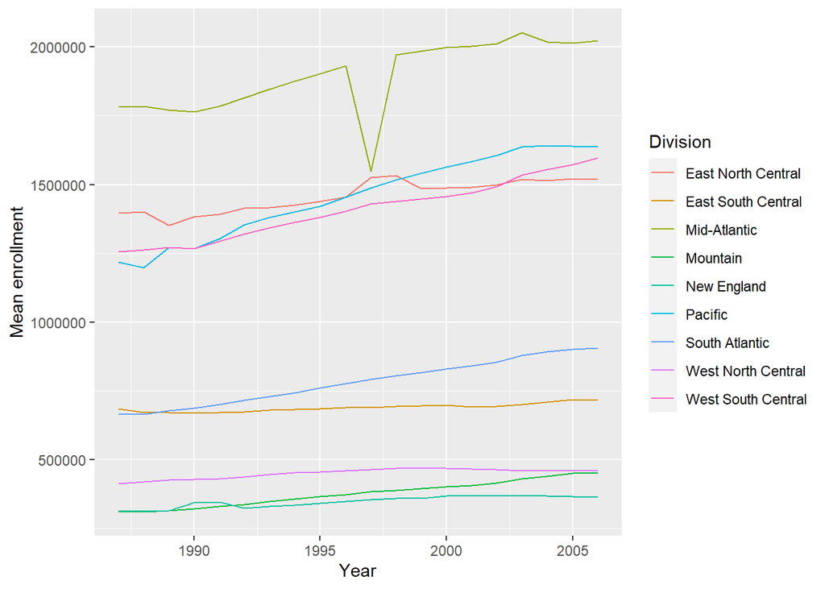

```r
plot(output_1_2_state,var_name="population")
```

Plot function on the county data frame **output_1_2_county** for different combinations for state of interest, the top or bottom values and for the number of records to be plotted. As this has class “county” associated with it the plot will check that and call `plot.county` under the hood.

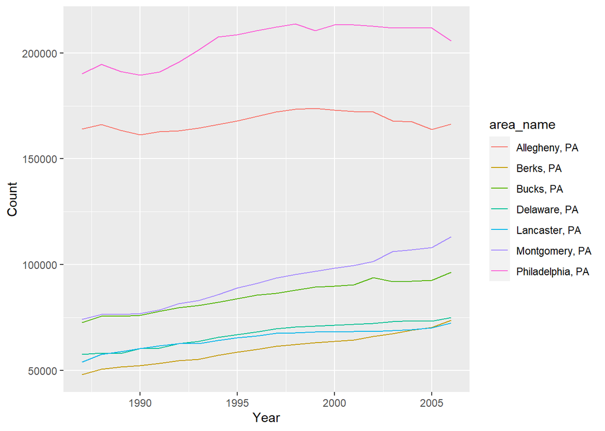

```r
plot(output_1_2_county,var_name="population",def_state="PA",group="top",num_find=7)
```

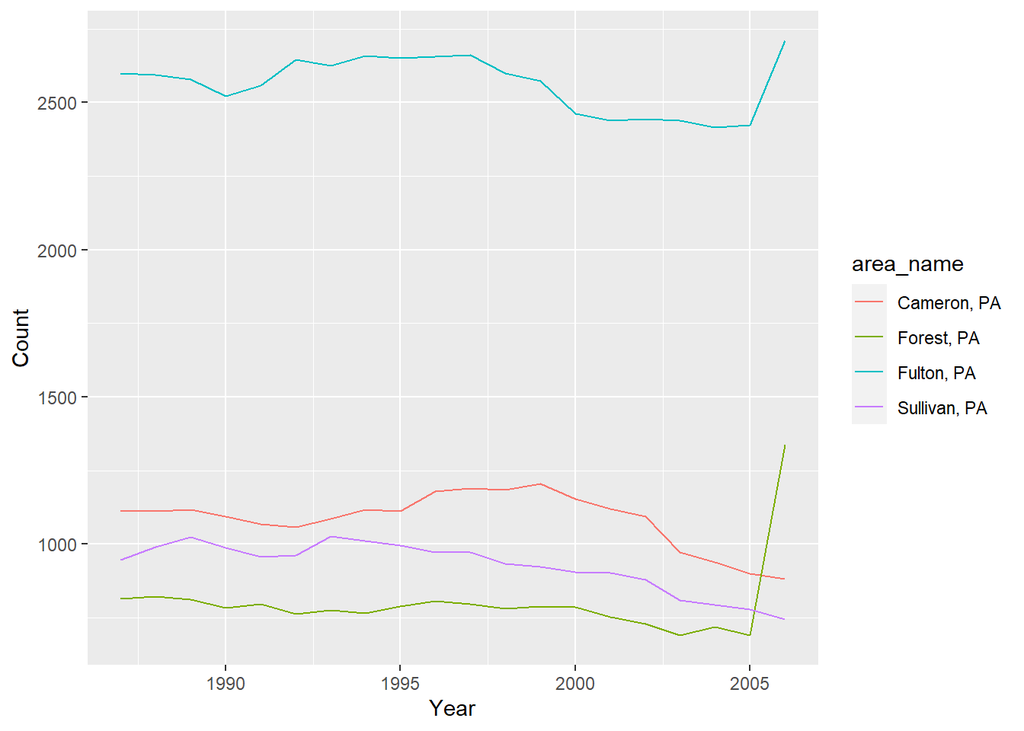

```r
plot(output_1_2_county,var_name="population",def_state="PA",group="bottom",num_find=4)
```

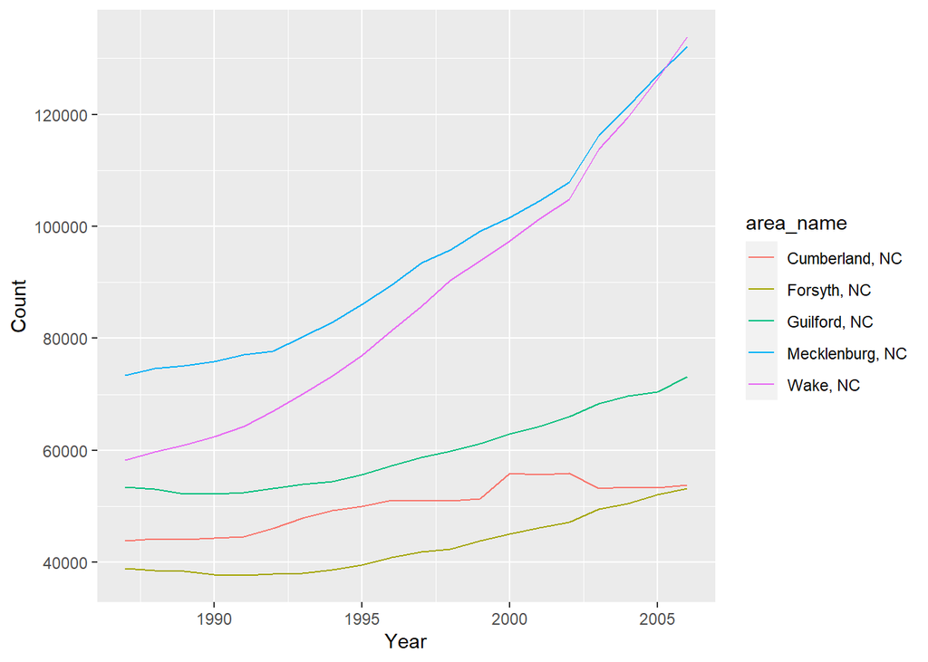

```r
plot(output_1_2_county,var_name="population")
```

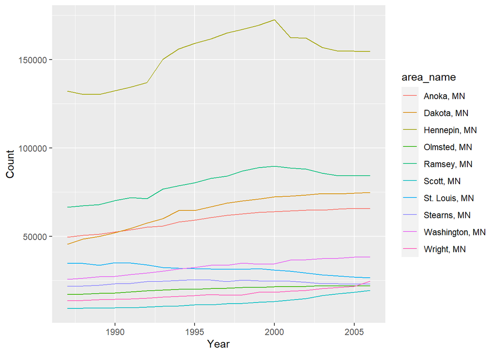

```r
plot(output_1_2_county,var_name="population",def_state="MN",group="top",num_find=10)
```

## Part2

Data processing function is run on the four enrollment URLs, enrollment data column is given the default value as no optional argument is passed here.

```r
output3 <- my_wrapper("https://www4.stat.ncsu.edu/~online/datasets/PST01a.csv")
output4 <- my_wrapper("https://www4.stat.ncsu.edu/~online/datasets/PST01b.csv")
output5 <- my_wrapper("https://www4.stat.ncsu.edu/~online/datasets/PST01c.csv")
output6 <- my_wrapper("https://www4.stat.ncsu.edu/~online/datasets/PST01d.csv")
```

The state tibbles and county tibbles from all the four csv files are vertically concatenated together to get **final_output_county** and **final_output_state**

```r
output_3_4 <- combine_data(output3,output4)
output_5_6 <- combine_data(output5,output6)
final_output <- combine_data(output_3_4,output_5_6)
final_output_county <- final_output$county
final_output_state <- final_output$state
final_output
```

```
## $county
## # A tibble: 125,800 × 8
##    area_name   STCOU item_id    enrollment_value enrollmen…¹  year count…² state
##    <chr>       <chr> <chr>                 <dbl> <chr>       <int> <chr>   <chr>
##  1 Autauga, AL 01001 PST015171D            25508 PST0151      1971 Autauga AL
##  2 Autauga, AL 01001 PST015172D            27166 PST0151      1972 Autauga AL
##  3 Autauga, AL 01001 PST015173D            28463 PST0151      1973 Autauga AL
##  4 Autauga, AL 01001 PST015174D            29266 PST0151      1974 Autauga AL
##  5 Autauga, AL 01001 PST015175D            29718 PST0151      1975 Autauga AL
##  6 Autauga, AL 01001 PST015176D            29896 PST0151      1976 Autauga AL
##  7 Autauga, AL 01001 PST015177D            30462 PST0151      1977 Autauga AL
##  8 Autauga, AL 01001 PST015178D            30882 PST0151      1978 Autauga AL
##  9 Autauga, AL 01001 PST015179D            32055 PST0151      1979 Autauga AL
## 10 Autauga, AL 01001 PST025181D            31985 PST0251      1981 Autauga AL
## # … with 125,790 more rows, and abbreviated variable names ¹enrollment_id,
## #   ²county_name
##
## $state
## # A tibble: 2,120 × 7
##    area_name   STCOU item_id    enrollment_value enrollment_id  year Division
##    <chr>       <chr> <chr>                 <dbl> <chr>         <int> <chr>
##  1 CONNECTICUT 09000 PST015171D          3061448 PST0151        1971 New England
##  2 CONNECTICUT 09000 PST015172D          3069617 PST0151        1972 New England
##  3 CONNECTICUT 09000 PST015173D          3069140 PST0151        1973 New England
##  4 CONNECTICUT 09000 PST015174D          3075784 PST0151        1974 New England
##  5 CONNECTICUT 09000 PST015175D          3084726 PST0151        1975 New England
##  6 CONNECTICUT 09000 PST015176D          3085984 PST0151        1976 New England
##  7 CONNECTICUT 09000 PST015177D          3088729 PST0151        1977 New England
##  8 CONNECTICUT 09000 PST015178D          3094839 PST0151        1978 New England
##  9 CONNECTICUT 09000 PST015179D          3099907 PST0151        1979 New England
## 10 CONNECTICUT 09000 PST025181D          3128849 PST0251        1981 New England
## # … with 2,110 more rows
```

Plot function on the state data frame **final_output_state**. As this has class “state” associated with it the plot will check that and call `plot.state` under the hood.

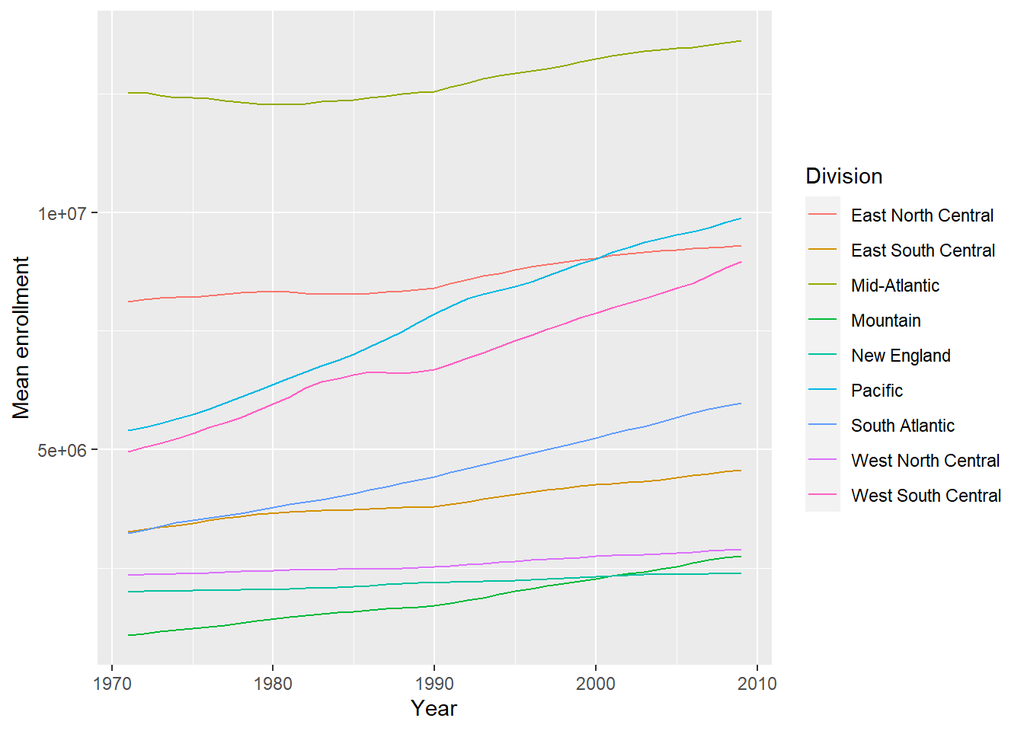

```r
plot(final_output_state)
```

Plot function on the county data frame **final_output_county** for different combinations for state of interest, the top or bottom values and for the number of records to be plotted. As this has class “county” associated with it the plot will check that and call `plot.county` under the hood.

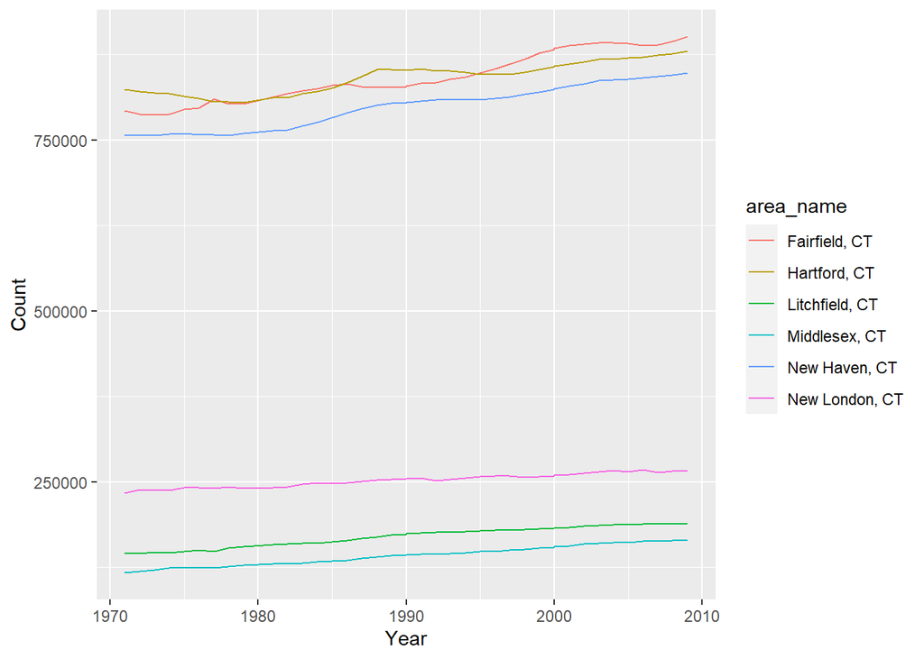

```r
plot(final_output_county,def_state="CT",group="top",num_find=6)
```

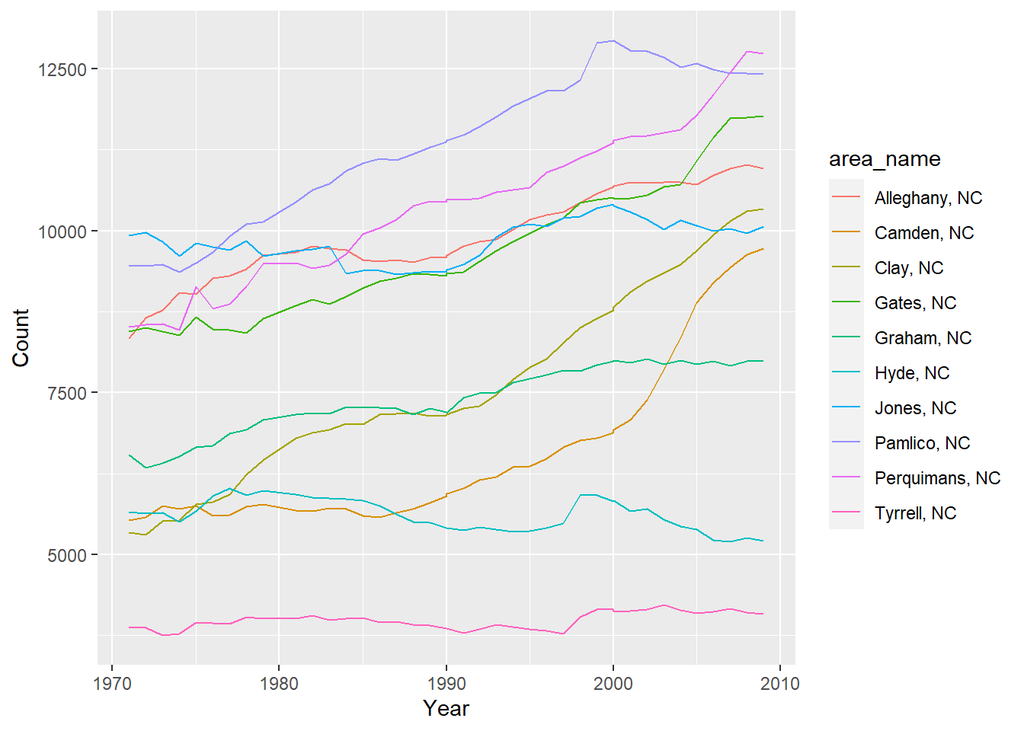

```r
plot(final_output_county,def_state="NC",group="bottom",num_find=10)
```

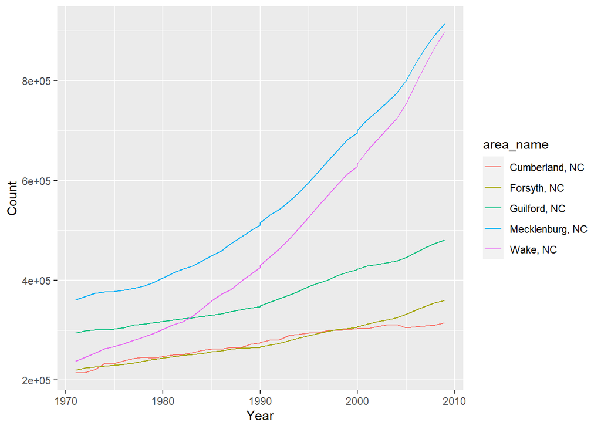

```r
plot(final_output_county)
```

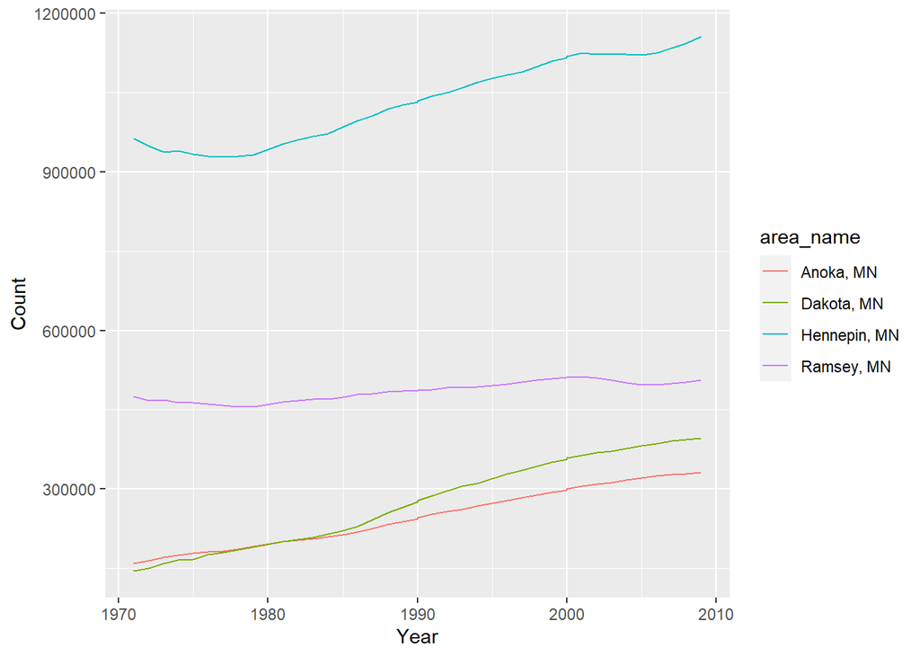

```r
plot(final_output_county,def_state="MN",group="top",num_find=4)
```